Skip to main content

# Preprocessing – From the PsychAD atlas to an analysable HBCC cohort

Donor selection, data reading, quality control, standard single-cell pipeline and pseudobulk matrix

Author

Myriam Sijlimassi

**NoteHow to read this notebook**

Each step starts with a short explanation of **what we do and why**, then the code. Every figure comes with:

- a **legend** (“Figure PP-Fxx”), written so that it can be copied into the report or the appendix;
- a **“How to read”** box, to understand the figure without knowing the method;
- an **“Interpretation”** box with the HBCC results.

The whole analysis runs in this notebook. The technical functions (reading the `.h5ad` file block by block, building the pseudobulk matrix, the selection criteria) are in `scripts/utils_h5ad.R` and `scripts/utils_donors.R`.

**First render: about 30 minutes plus the download** (the `.h5ad` file of the HBCC cohort weighs about 14 GB and is downloaded once into `01_DATA/raw/`). The three heavy steps (nucleus metadata, Seurat object, pseudobulk matrix) save their result in `01_DATA/processed/`; the next renders reload these files and take about one minute. To recompute a step, delete its file.

Figures are saved as `.png` (300 dpi) in `04_FIGURES/preprocessing/`. References are numbered in square brackets and listed at the end.

# Overview

## Question and role of the preprocessing

**Central question of the project.** Do schizophrenia (SCZ) and bipolar disorder (BD) share cell-type-specific molecular alterations in the human prefrontal cortex, and could these changes reflect accelerated ageing and affect neuronal and glial signalling networks?

**Role of this notebook.** The PsychAD atlas [1] contains 6.3 million nuclei from 1,494 donors and several brain banks. We extract from it a cohort that can answer the question without obvious bias, and we prepare the data sets used by Q1 to Q5:

| Output | Content | Used by |
| --- | --- | --- |
| Donor selection | 224 donors, Table 1, inclusion and exclusion criteria, E7 table | every question |
| Nuclei per donor and subclass | number of nuclei of each subclass in each donor (all nuclei) | Q1 (composition) |
| Seurat object | about 45,000 nuclei (at most 200 per donor), normalised, PCA, UMAP | visualisation, Q4 (CellChat) |
| Pseudobulk matrix | 34,176 genes x 6,048 columns (donor x subclass), raw counts | Q2 (differential expression), Q5 |

## The principle behind every step

**We compare people, not cells.** A brain that gives 5,000 nuclei is still one person. Treating nuclei as independent samples (pseudoreplication) makes p-values far too small [2]. Every test of the project is therefore done at the **donor** level, and the preprocessing is built for that.

## Plan

The notebook has two parts: first we decide **who we compare** (study design), then we prepare **the data** of these donors (data processing).

| Part | Step | What we do | Output |
| --- | --- | --- | --- |
| A – Study design | 1 | The data: download the HBCC file, read the table of the nuclei | 1,486,324 nuclei, 300 donors |
|  | 2 | Donor selection (inclusion and exclusion criteria) | flow table, PP-F01 |
|  | 3 | Description of the groups (Table 1) and check of the clinical information | tables, PP-F02 |
|  | 4 | Sensitivity analyses: group sizes when one criterion changes | table |
|  | 5 | Cell types per donor (input of Q1) | E7 table |
| B – Data processing | 6 | Reading the data, one donor at a time | Seurat object |
|  | 7 | Quality control | PP-F03 |
|  | 8 | Normalisation and visual check of the cell types (PCA, UMAP, marker genes) | PP-F04 to PP-F07 |
|  | 9 | Pseudobulk (input of Q2 and Q5) | pseudobulk matrix |

# Setup

| Package | Used for |
| --- | --- |
| `rhdf5`, `Matrix` | reading the `.h5ad` file block by block, sparse matrices |
| `Seurat` | normalisation, HVG, scaling, PCA, UMAP [3] |
| `ggplot2`, `knitr` | figures and tables |

```r
the.seed <- 2026
set.seed(the.seed)

suppressPackageStartupMessages({
  library(ggplot2)
  library(knitr)
  library(Matrix)
  library(rhdf5)
  library(Seurat)
})

source("scripts/utils_figures.R")   # common figure style, colours and saving (shared with the other notebooks)
source("scripts/utils_h5ad.R")      # reading the .h5ad file block by block, pseudobulk
source("scripts/utils_donors.R")    # donor table, diagnoses, selection criteria, Table 1
```

All our choices are gathered in one place. They were **fixed before looking at any result**.

| Parameter | Value | Why |
| --- | --- | --- |
| `age_min` | 20 years | end of the developmental transcriptomic remodelling of the cortex [4] |
| `keep_tardive_dyskinesia` | yes | part of the real clinical picture of SCZ (side effect of antipsychotics) |
| `keep_metabolic_controls` | yes | controls with diabetes or atherosclerosis are tolerated in [1] |
| `nuclei_min` | 20 nuclei | minimum number of nuclei of a cell type in a donor for a usable pseudobulk sample (criterion E7) |
| covariates | age, sex, genetic ancestry | ancestry is strongly unbalanced between groups (Step 3); no post-mortem interval in the file |
| `max_nuclei_per_donor` | 200 | random subsample used only for the Seurat object, so that every donor weighs the same |

```r
# Data: PsychAD atlas on CELLxGENE, HBCC cohort (one brain bank, 300 donors, dorsolateral prefrontal cortex)
h5ad_url  <- "https://datasets.cellxgene.cziscience.com/d27fb144-f105-46c2-b36f-f51421f74e4e.h5ad"
h5ad_file <- "../01_DATA/raw/HBCC_Cohort.h5ad"

# Outputs
proc_dir <- "../01_DATA/processed"            # data prepared here and used by the next notebooks
pre_dir  <- "../03_RESULTS/preprocessing"     # results shown in this notebook (tables)
fig_dir  <- "../04_FIGURES/preprocessing"
for (d in c(proc_dir, pre_dir, fig_dir)) dir.create(d, recursive = TRUE, showWarnings = FALSE)

meta_file       <- file.path(proc_dir, "meta_nuclei_HBCC.rds")
seurat_file     <- file.path(proc_dir, "seurat_object_HBCC_224donors.rds")
pseudobulk_file <- file.path(proc_dir, "pseudobulk_HBCC_224donors.rds")

# Analysis choices
age_min                 <- 20
keep_tardive_dyskinesia <- TRUE
keep_metabolic_controls <- TRUE
nuclei_min              <- 20
max_nuclei_per_donor    <- 200

# Colours of the groups, the same in every figure of the project (blue = SCZ, red = BD)
col_groups <- c(Control = "grey60", SCZ = "#2166ac", BD = "#b2182b")
```

# Part A – Study design: who do we compare?

Before looking at any gene, we decide which donors are compared, with criteria fixed in advance, as for a clinical trial. This part only uses the table of the nuclei (donor, diagnoses, age, sex, ancestry, cell type), not the gene expression.

## Step 1 – The data

**What we do and why.** The data come from the PsychAD atlas [1], which is shared on CELLxGENE as one file per brain bank. We use the file of the **HBCC** bank (NIMH Human Brain Collection Core): 1,486,324 nuclei from 300 donors, about 14 GB. The file is downloaded once and kept in `01_DATA/raw/`.

```r
# The data set is downloaded from its CELLxGENE link (h5ad_url, defined in the parameters).
# If the complete file is already in 01_DATA/raw/, it is used as it is.
if (!file.exists(h5ad_file)) {
  dir.create(dirname(h5ad_file), recursive = TRUE, showWarnings = FALSE)
  options(timeout = 36000)                                    # large file: allow a long download
  download.file(h5ad_url, paste0(h5ad_file, ".part"), mode = "wb")
  file.rename(paste0(h5ad_file, ".part"), h5ad_file)          # renamed only once the download is complete
}
file.size(h5ad_file) / 1e9                                    # size in GB (about 14)
```

```
[1] 14.15053
```

**The nucleus metadata.** The file contains a table with one row per nucleus: its donor, the donor’s diagnoses, age, sex and ancestry, and the cell type of the nucleus. To select the donors, we only need this table, not the gene expression, so we read only this part of the file.

```r
obs_columns <- c("donor_id", "disease", "development_stage", "sex", "genetic_ancestry", "self_reported_ethnicity",
                 "Schizophrenia", "Bipolar_Disorder", "AD_status", "ASCVD_status", "DLBD_status", "FTD_status",
                 "Parkinson_disease", "Tardive_dyskinesia", "Tauopathy_status", "Vascular_status", "Source",
                 "class", "subclass", "subtype", "n_counts", "n_genes")

if (!file.exists(meta_file)) {
  meta <- read_h5ad_obs(h5ad_file, obs_columns)
  saveRDS(meta, meta_file)
}
meta <- readRDS(meta_file)

dim(meta)                                   # one row per nucleus
```

```
[1] 1486324      22
```

```r
c(donors = length(unique(meta$donor_id)),   # expected: 300 donors
  subclasses = length(unique(meta$subclass)))
```

```
    donors subclasses
       300         27
```

```r
table(meta$Source)                          # H = HBCC only
```

```
      H
1486324
```

## Step 2 – Donor selection

**What we do and why.** We start from the 300 donors of the HBCC brain bank. Using a single bank avoids mixing a difference between banks with a difference between diseases (a “site” confounder). We then apply inclusion and exclusion criteria, as for a clinical trial, starting from the group definitions of Lee et al. [1] and making them stricter on two points.

**From nuclei to donors.** We keep one row per donor: we want to count people, not nuclei. The age is written as text (“45-year-old stage”, “8-month-old stage”): we convert it to years.

```r
donors <- donors_from_nuclei(meta)
donors$age <- parse_age(donors$development_stage)

nrow(donors)                                        # expected: 300 donors
```

```
[1] 300
```

```r
unique(donors$development_stage[is.na(donors$age)]) # only "unknown" is expected here: one donor without age, excluded by E6
```

```
[1] unknown
79 Levels: 2-year-old stage 3-year-old stage ... unknown
```

```r
summary(donors$age)
```

```
    Min.  1st Qu.   Median     Mean  3rd Qu.     Max.      NAs
 0.08333 23.50000 41.00000 38.63657 53.00000 85.00000        1
```

**One TRUE/FALSE column per diagnosis.** The `disease` column lists all the diagnoses of a donor, separated by `||` (for example `schizophrenia || type 2 diabetes mellitus || tardive dyskinesia`). `flag_diagnoses()` creates one column per diagnosis; whatever is left after removing the known diagnoses is an “other diagnosis” (OCD, epilepsy…). Schizoaffective disorder of bipolar type contains the word “bipolar”, so it is flagged first and removed from the text.

```r
donors <- flag_diagnoses(donors)

table(donors$other_diagnosis[donors$has_other_diagnosis])    # the other diagnoses present
```

```
attention deficit-hyperactivity disorder
                                       2
                          brain neoplasm
                                       1
                                epilepsy
                                       2
               major depressive disorder
                                       1
           obsessive-compulsive disorder
                                       6
          post-traumatic stress disorder
                                       1
```

```r
table(SCZ = donors$has_SCZ, BD = donors$has_BD)              # SCZ crossed with BD (donors)
```

```
       BD
SCZ     FALSE TRUE
  FALSE   180   68
  TRUE     52    0
```

**The criteria.** Each criterion is one line of `select_donors()`. A donor is counted once, at the first criterion it fails.

| Criterion | Rule | Why |
| --- | --- | --- |
| I2 | age at death >= 20 years | before 20, the cortex is still maturing [4]: young controls versus adult patients would create a false difference |
| E1 | not both SCZ and BD | a donor cannot be in both groups we compare |
| E2 | no schizoaffective disorder, bipolar type | in [1] these donors are counted in both SCZ and BD |
| E4, E5 | no other brain disorder (dementia, epilepsy, other psychiatric diagnosis) | it would change the cells independently of SCZ or BD (“no secondary diagnosis” rule of [1]) |
| E6 | no missing covariate | age, sex and ancestry are needed in every model |
| kept on purpose | tardive dyskinesia; controls with diabetes or atherosclerosis | part of the real clinical picture; metabolic disorders are tolerated in [1] |

```r
selection <- select_donors(donors, age_min = age_min,
                           keep_td = keep_tardive_dyskinesia,
                           keep_metabolic_controls = keep_metabolic_controls)
donors$group            <- selection$group
donors$exclusion_reason <- selection$reason

sel <- donors[donors$group != "Excluded", ]
sel$group <- factor(sel$group, levels = c("Control", "SCZ", "BD"))
table(sel$group)
```

```
Control     SCZ      BD
    121      49      54
```

```r
flow <- as.data.frame(table(donors$exclusion_reason))
names(flow) <- c("Criterion", "Donors excluded")
flow_display <- rbind(flow, data.frame(Criterion = paste0("Total excluded (", nrow(donors), " -> ", nrow(sel), ")"),
                                       "Donors excluded" = sum(flow[[2]]), check.names = FALSE))
flow_display
```

| Criterion | Donors excluded |
| --- | --- |
| E2 - schizoaffective disorder, bipolar type | 4 |
| E4 - other diagnosis (patient) | 13 |
| E6 - missing data | 1 |
| I2 - age below threshold | 58 |
| Total excluded (300 -> 224) | 76 |

**TipHow to read**

Flow of the donors through the criteria (CONSORT-like table): each row is a criterion and the number of donors it removed. The criteria are applied in order, so a donor is counted once, at the first criterion it fails.

```
    Kruskal-Wallis rank sum test

data:  age by group
Kruskal-Wallis chi-squared = 12.288, df = 2, p-value = 0.002146
```

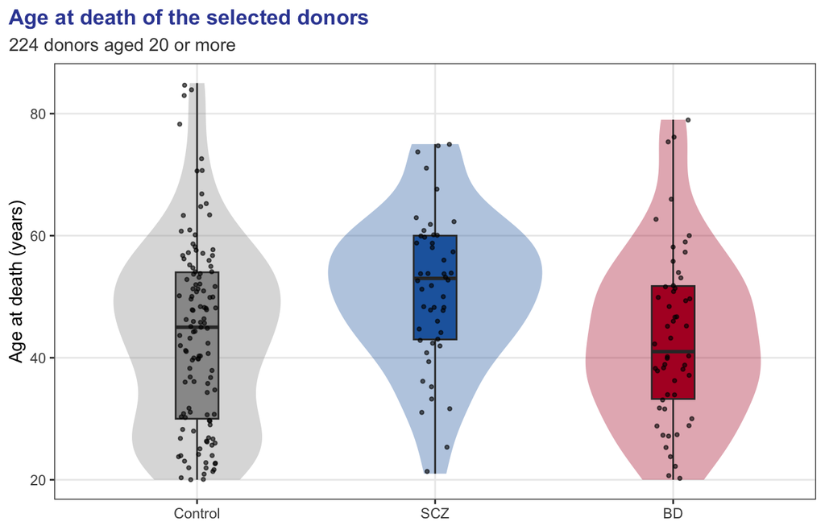

Figure 1

```r
p_PP_F01 <- ggplot(sel, aes(group, age, fill = group)) +
  geom_violin(alpha = 0.35, colour = NA) +
  geom_boxplot(width = 0.18, outlier.shape = NA) +
  geom_jitter(width = 0.08, size = 0.8, alpha = 0.6) +
  scale_fill_manual(values = col_groups, guide = "none") +
  labs(x = NULL, y = "Age at death (years)",
       title = "Age at death of the selected donors",
       subtitle = paste0(nrow(sel), " donors aged ", age_min, " or more")) +
  theme_project()
p_PP_F01
save_figure(p_PP_F01, "PP_F01_age_by_group", fig_dir, width = 7, height = 4.5)

age_test <- kruskal.test(age ~ group, data = sel)   # do the ages differ between groups? (descriptive)
age_test
```

**Figure PP-F01 – Age at death of the selected donors, per group.** Violin plot, box plot (median and interquartile range) and individual donors (dots). Only donors aged 20 years or more were kept.

**TipHow to read**

Each dot is a donor. The box gives the median and the middle half of the ages. If the three violins overlap well, age cannot fully explain a difference between groups; it is still adjusted for in every model.

**ImportantInterpretation**

- **224 donors kept out of 300**: 121 controls, 49 SCZ and 54 BD.
- Median ages differ a little between groups (Kruskal-Wallis p = 0.002), but the distributions overlap widely: we treat age as a covariate of every model rather than as a reason to exclude more donors.
- The criterion with the largest effect is the age threshold (58 donors under 20, almost all controls). Thresholds of 17 and 24 years are sensitivity analyses (Step 4).

## Step 3 – Description of the groups

**What we do and why.** Before comparing patients with controls, we check that they are similar on everything else (Table 1, balance of covariates). We also check that the clinical columns of the file agree with the text of the diagnoses (metadata quality control).

```r
table1 <- make_table1(sel)
row_labels <- c(N = "Donors (n)", Age_median = "Median age at death (years)", Age_min = "Minimum age (years)",
                Age_max = "Maximum age (years)", Women = "Women, n (%)", Atherosclerosis = "Atherosclerosis, n (%)",
                Diabetes = "Diabetes, n (%)", Tardive_dyskinesia = "Tardive dyskinesia, n (%)",
                Nuclei_median = "Median number of nuclei per donor")
data.frame(Characteristic = row_labels[rownames(table1)], table1, check.names = FALSE, row.names = NULL)
```

| Characteristic | Control | SCZ | BD |
| --- | --- | --- | --- |
| Donors (n) | 121 | 49 | 54 |
| Median age at death (years) | 45 | 53 | 41 |
| Minimum age (years) | 20 | 21 | 20 |
| Maximum age (years) | 85 | 75 | 79 |
| Women, n (%) | 35 (29 %) | 21 (43 %) | 23 (43 %) |
| Atherosclerosis, n (%) | 26 (21 %) | 6 (12 %) | 6 (11 %) |
| Diabetes, n (%) | 9 (7 %) | 13 (27 %) | 5 (9 %) |
| Tardive dyskinesia, n (%) | 0 (0 %) | 12 (24 %) | 0 (0 %) |
| Median number of nuclei per donor | 5395.0 | 4784.0 | 4223.5 |

|  | Control | SCZ | BD |
| --- | --- | --- | --- |
| European | 43 | 12 | 45 |
| South Asian | 1 | 1 | 0 |
| East Asian | 2 | 1 | 2 |
| African | 70 | 32 | 4 |
| unknown | 5 | 3 | 3 |

Figure 2

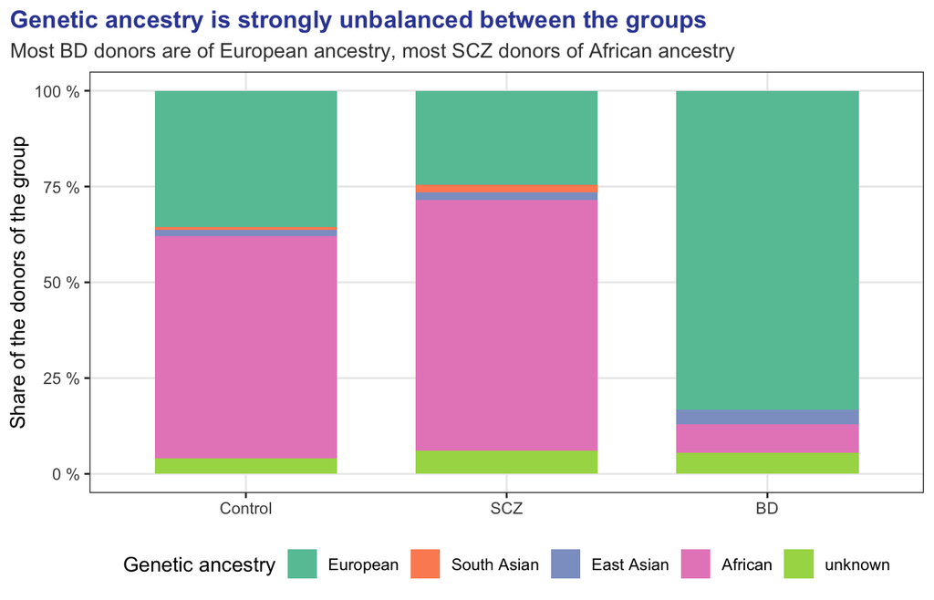

Figure 3

```r
ancestry_table <- as.data.frame(table(ancestry = sel$genetic_ancestry, group = sel$group))
ancestry_table <- ancestry_table[ancestry_table$Freq > 0, ]

p_PP_F02 <- ggplot(ancestry_table, aes(group, Freq, fill = ancestry)) +
  geom_col(position = "fill", width = 0.7) +
  scale_y_continuous(labels = function(x) paste0(round(100 * x), " %")) +
  scale_fill_brewer(palette = "Set2", name = "Genetic ancestry") +
  labs(x = NULL, y = "Share of the donors of the group",
       title = "Genetic ancestry is strongly unbalanced between the groups",
       subtitle = "Most BD donors are of European ancestry, most SCZ donors of African ancestry") +
  theme_project()
p_PP_F02
save_figure(p_PP_F02, "PP_F02_ancestry_by_group", fig_dir, width = 7, height = 4.5)

ancestry_counts <- table(droplevels(sel$genetic_ancestry), sel$group)
as.data.frame.matrix(ancestry_counts)
```

**Figure PP-F02 – Genetic ancestry of the donors, per group.** Share of each genetic ancestry among the donors of each group (counts in the table below the figure).

**TipHow to read**

Each bar is one group and adds up to 100 %. If the colours had the same shares in the three bars, ancestry would be balanced. Here they clearly do not.

**ImportantInterpretation**

- **This is the most serious limit of the project.** BD donors are mostly of European ancestry (45 of 54) and SCZ donors mostly of African ancestry (32 of 49). Genetic ancestry changes the expression of some genes (eQTL), so comparing SCZ with BD is partly comparing two ancestries (confounding between diagnosis and ancestry).
- How we handle it: ancestry is a covariate of every model, SCZ vs BD is interpreted with caution, and Q1 adds analyses stratified by ancestry. Controls are better balanced (70 African, 43 European), so each disease can be compared with controls of the same ancestry.
- Tardive dyskinesia is only found in SCZ (12 (24 %)), as expected for a side effect of antipsychotics.

```r
# All 300 donors, with every column of the file
all_donors <- meta[!duplicated(meta$donor_id), ]
all_donors$disease <- as.character(all_donors$disease)

metadata_qc <- rbind(
  metadata_agreement(all_donors, "Schizophrenia",      "schizophrenia|schizoaffective"),
  metadata_agreement(all_donors, "Bipolar_Disorder",   "bipolar"),
  metadata_agreement(all_donors, "ASCVD_status",       "atherosclerosis"),
  metadata_agreement(all_donors, "Tardive_dyskinesia", "tardive dyskinesia"))
setNames(metadata_qc, c("Column of the file", "Positive in the column", "Positive in the diagnosis text",
                        "Positive in both", "Discordant"))
```

| Column of the file | Positive in the column | Positive in the diagnosis text | Positive in both | Discordant |
| --- | --- | --- | --- | --- |
| Schizophrenia | 56 | 56 | 56 | 0 |
| Bipolar_Disorder | 69 | 69 | 69 | 0 |
| ASCVD_status | 40 | 40 | 40 | 0 |
| Tardive_dyskinesia | 28 | 14 | 3 | 36 |

```r
# Selected controls marked "Yes" in the Tardive_dyskinesia column
td_controls <- sum(sel$Tardive_dyskinesia == "Yes" & sel$group == "Control")
```

**TipHow to read**

For each yes/no column of the file, agreement with the text of the diagnoses (300 donors). A column with discordant donors cannot be trusted.

**ImportantInterpretation**

- The schizophrenia, bipolar disorder and atherosclerosis columns agree 100 % with the diagnoses.
- The `Tardive_dyskinesia` column does not (36 discordant donors, including 10 selected controls marked “Yes”), so we use the text of the diagnoses instead.
- The post-mortem interval (PMI) is not in the file: our covariates are limited to age, sex and ancestry.

## Step 4 – Sensitivity analyses

**What we do and why.** We repeat the selection, changing one parameter at a time. These variants are used by the sensitivity analyses of the next questions.

```r
variants <- list(
  main                       = selection,
  age_17                     = select_donors(donors, 17,      keep_tardive_dyskinesia, keep_metabolic_controls),
  age_24                     = select_donors(donors, 24,      keep_tardive_dyskinesia, keep_metabolic_controls),
  without_tardive_dyskinesia = select_donors(donors, age_min, FALSE,                   keep_metabolic_controls),
  strict_controls            = select_donors(donors, age_min, keep_tardive_dyskinesia, FALSE),
  schizoaff_bipolar_to_SCZ   = select_donors(donors, age_min, keep_tardive_dyskinesia, keep_metabolic_controls, "SCZ"),
  schizoaff_bipolar_to_BD    = select_donors(donors, age_min, keep_tardive_dyskinesia, keep_metabolic_controls, "BD"))

group_levels <- c("Control", "SCZ", "BD", "Excluded")
sensitivity_group_sizes <- t(sapply(variants, function(v) table(factor(v$group, levels = group_levels))))
sensitivity_group_sizes
```

```
                           Control SCZ BD Excluded
main                           121  49 54       76
age_17                         130  49 55       66
age_24                         109  48 51       92
without_tardive_dyskinesia     121  37 54       88
strict_controls                 88  49 54      109
schizoaff_bipolar_to_SCZ       121  53 54       72
schizoaff_bipolar_to_BD        121  49 58       72
```

```r
# The group of each donor in each variant, kept for the next questions
donors$group_age17          <- variants$age_17$group
donors$group_age24          <- variants$age_24$group
donors$group_without_TD     <- variants$without_tardive_dyskinesia$group
donors$group_strict_control <- variants$strict_controls$group
donors$group_sab_SCZ        <- variants$schizoaff_bipolar_to_SCZ$group
donors$group_sab_BD         <- variants$schizoaff_bipolar_to_BD$group
```

## Step 5 – Cell types per donor (input of Q1)

**What we do and why.** For the composition analysis (Q1), all we need is the number of nuclei of each of the 27 subclasses in each selected donor, using **all** their nuclei. We also count, for each subclass, how many donors of each group have at least 20 nuclei of it (criterion E7): a subclass that is too rare cannot be analysed in pseudobulk.

```r
meta_sel <- meta[meta$donor_id %in% sel$donor_id, ]
nuclei_donor_subclass <- table(as.character(meta_sel$donor_id), as.character(meta_sel$subclass))
nuclei_donor_subclass <- nuclei_donor_subclass[sel$donor_id, ]
dim(nuclei_donor_subclass)                       # donors x subclasses
```

```
[1] 224  27
```

```r
sum(nuclei_donor_subclass)                       # nuclei of the selected donors
```

```
[1] 1123085
```

```r
E7 <- donors_per_subclass(nuclei_donor_subclass, as.character(sel$group), nuclei_min)
E7[order(apply(E7, 1, min)), ]                   # rarest subclasses first
```

```
              Control SCZ BD
EN_L5_ET            0   0  0
Adaptive           10   1  3
PVM                22   3  6
SMC                12   9  8
EN_L6_IT_2         55  19 26
VLMC               60  22 23
EN_L6B             74  25 33
EN_L5_6_NP         83  27 35
EN_L6_IT_1         82  27 35
IN_LAMP5_LHX6      90  29 40
EN_L6_CT           86  31 35
PC                 91  31 38
IN_PVALB_CHC       96  34 42
IN_ADARB2          96  37 38
IN_LAMP5_RELN     103  38 46
Micro             112  38 46
EN_L3_5_IT_1       95  39 40
EN_L3_5_IT_3      106  39 45
Endo              109  40 40
IN_PVALB          110  41 49
EN_L3_5_IT_2      109  42 46
IN_SST            112  42 48
Astro             118  44 53
EN_L2_3_IT        113  45 48
IN_VIP            113  45 51
OPC               120  45 53
Oligo             121  46 52
```

```r
write.csv(flow, file.path(pre_dir, "flow_diagram.csv"), row.names = FALSE)
write.csv(table1, file.path(pre_dir, "table1.csv"))
write.csv(sensitivity_group_sizes, file.path(pre_dir, "sensitivity_group_sizes.csv"))
write.csv(metadata_qc, file.path(pre_dir, "metadata_qc.csv"), row.names = FALSE)
# Data used by the next notebooks
write.csv(donors, file.path(proc_dir, "donor_classification.csv"), row.names = FALSE)
saveRDS(donors, file.path(proc_dir, "donor_classification.rds"))
write.csv(as.data.frame.matrix(nuclei_donor_subclass), file.path(proc_dir, "nuclei_donor_x_subclass.csv"))
write.csv(E7, file.path(pre_dir, "E7_donors_per_subclass.csv"))
```

# Part B – Data processing: are the data usable, and in which form?

Now that the donors are chosen, we read their gene expression, check its quality, and put it in the two forms used by the next questions: a Seurat object (one column per nucleus) and a pseudobulk matrix (one column per donor and cell type).

## Step 6 – Reading the data

**What we do and why.** The data set is too large to be loaded at once in the memory of a computer (1.5 million nuclei). We therefore read the file **one donor at a time**: we read the nuclei of a donor, keep what we need, free the memory, then move to the next donor. This works because the nuclei of each donor are stored next to each other in the file (checked for every donor). The reading functions are in `scripts/utils_h5ad.R`.

**Raw counts?** The file has no `raw/` layer, so the matrix `X` should hold the raw counts. We read the first million values and check that they are integers.

```r
test_values <- as.numeric(h5read(h5ad_file, "/X/data", index = list(1:1e6)))
h5closeAll()
all(test_values == round(test_values))     # TRUE = integers = raw counts
```

```
[1] TRUE
```

```r
summary(test_values)
```

```
    Min.  1st Qu.   Median     Mean  3rd Qu.     Max.
   1.000    1.000    1.000    3.898    3.000 3205.000
```

**The subsample for the Seurat object.** For the standard single-cell pipeline (visualisation, annotation check, CellChat in Q4), we randomly draw at most 200 nuclei per selected donor, so that every donor weighs the same. The pseudobulk matrix (Step 9) uses **all** the nuclei.

```r
gene_table <- read_gene_names(h5ad_file)
nrow(gene_table)                                     # expected: 34,176 genes
```

```
[1] 34176
```

```r
head(gene_table)                                     # Ensembl identifier and gene symbol
```

| ensembl_id | symbol | name |
| --- | --- | --- |
| ENSG00000000003 | TSPAN6 | TSPAN6 |
| ENSG00000000005 | TNMD | TNMD |
| ENSG00000000419 | DPM1 | DPM1 |
| ENSG00000000457 | SCYL3 | SCYL3 |
| ENSG00000000460 | FIRRM | FIRRM |
| ENSG00000000938 | FGR | FGR |

```r
rows_by_donor  <- rows_per_donor(meta, sel$donor_id)
chosen_nuclei  <- draw_nuclei(rows_by_donor, max_nuclei_per_donor, seed = the.seed)
kept_rows      <- unlist(chosen_nuclei)
length(kept_rows)                                    # nuclei in the Seurat object
```

```
[1] 44588
```

```r
if (!file.exists(seurat_file)) {
  # 1. Read the drawn nuclei, donor by donor (about 7 minutes)
  counts <- read_chosen_nuclei(h5ad_file, chosen_nuclei, gene_table$name)

  # 2. Metadata of each nucleus, with the information of its donor
  meta_nuclei <- meta[kept_rows, c("donor_id", "class", "subclass", "subtype", "n_counts", "n_genes")]
  rownames(meta_nuclei) <- colnames(counts)
  position <- match(as.character(meta_nuclei$donor_id), sel$donor_id)
  meta_nuclei$group    <- as.character(sel$group[position])
  meta_nuclei$age      <- sel$age[position]
  meta_nuclei$sex      <- sel$sex[position]
  meta_nuclei$ancestry <- as.character(sel$genetic_ancestry[position])

  obj <- CreateSeuratObject(counts = counts, meta.data = meta_nuclei, project = "HBCC_SCZ_BD")
  rm(counts); invisible(gc())

  # 3. The UMAP computed by the authors, to compare it with ours
  umap_authors <- t(h5read(h5ad_file, "/obsm/X_umap")[, kept_rows])
  h5closeAll()
  rownames(umap_authors) <- colnames(obj)
  colnames(umap_authors) <- c("umapAuthors_1", "umapAuthors_2")
  obj[["umap_authors"]] <- CreateDimReducObject(embeddings = umap_authors, key = "umapAuthors_", assay = "RNA")

  saveRDS(obj, seurat_file)        # saved now, and again after the pipeline of Step 8
}
obj <- readRDS(seurat_file)
obj
```

```
An object of class Seurat
34176 features across 44588 samples within 1 assay
Active assay: RNA (34176 features, 2000 variable features)
 3 layers present: counts, data, scale.data
 3 dimensional reductions calculated: umap_authors, pca, umap
```

**Is the reading correct?** We compare the total counts of each nucleus with the `n_counts` column computed by the authors.

```r
read_counts      <- obj$nCount_RNA
authors_counts <- meta$n_counts[kept_rows]
summary(read_counts / authors_counts)     # expected: values between 0.98 and 1
```

```
   Min. 1st Qu.  Median    Mean 3rd Qu.    Max.
 0.9817  0.9938  0.9950  0.9949  0.9961  1.0000
```

```r
cor(read_counts, authors_counts)          # expected: a correlation close to 1
```

```
[1] 0.9999984
```

**TipWhy we check a ratio and not an exact equality**

Our totals are slightly lower than the authors’ (by about 0.5 %) but perfectly correlated with them. A reading error would give random differences and a low correlation: the reading is correct. The small gap probably comes from a longer gene list used by the authors to compute their totals (not tested).

## Step 7 – Quality control

**What we do and why.** The authors had already filtered the nuclei [1]. We did not filter again, to stay comparable with the atlas; we checked the distributions on the subsample.

```r
obj[["percent_mt"]] <- PercentageFeatureSet(obj, pattern = "^MT-")    # mitochondrial genes (human names start with MT-)

p_PP_F03 <- VlnPlot(obj, features = c("nCount_RNA", "nFeature_RNA", "percent_mt"),
                    group.by = "group", pt.size = 0, ncol = 3, cols = col_groups)
p_PP_F03
save_figure(p_PP_F03, "PP_F03_qc_by_group", fig_dir, width = 10, height = 4)

qc_summary <- sapply(c("nCount_RNA", "nFeature_RNA", "percent_mt"), function(v) summary(obj[[v]][, 1]))
round(qc_summary, 2)
```

```
        nCount_RNA nFeature_RNA percent_mt
Min.       1211.00       983.00       0.00
1st Qu.    4594.00      2325.00       0.03
Median     8335.00      3378.50       0.08
Mean      14602.48      4116.32       0.14
3rd Qu.   18297.00      5557.25       0.17
Max.     165175.00     13885.00       1.00
```

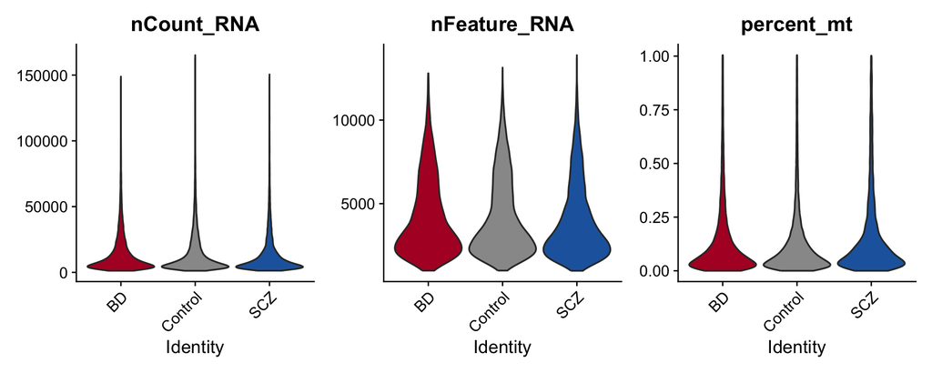

Figure 4

```r
median_counts <- tapply(obj$nCount_RNA, obj$group, median)
```

**Figure PP-F03 – Quality of the nuclei, per group.** Number of RNA molecules per nucleus (`nCount_RNA`), number of detected genes (`nFeature_RNA`) and percentage of mitochondrial reads (`percent_mt`, human pattern `^MT-`), on 44,588 nuclei (at most 200 per donor).

**TipHow to read**

One violin per group and per measure. Similar violins in the three groups mean that the data quality does not differ between controls and patients.

**ImportantInterpretation**

- Sharp bounds (never fewer than 983 genes, never more than 1 % mitochondrial reads) show that a filter has already been applied upstream.
- **Mitochondrial reads are almost absent (median 0.08 %)** because these are nuclei: mitochondria are in the cytoplasm (single-nucleus RNA-seq). The 5-20 % thresholds used for whole cells do not apply here.
- SCZ nuclei have about 7 % fewer molecules than controls (medians). This is a nucleus-level description, not a test; depth differences are corrected by the normalisation of each sample.
- No knee plot can be drawn: the file contains only the nuclei retained by the authors, not all the droplets.

## Step 8 – Normalisation and visual check of the cell types (PCA, UMAP)

**What we do and why.** We follow the steps of the course on the subsample. The upstream steps (alignment, filtering, annotation) were done by the authors on the whole atlas [1]: we checked them rather than redoing them.

| Step of the pipeline (course video) | What it is for | What we did |
| --- | --- | --- |
| Experimental design (01) | decide who is compared with whom | 224 donors, one bank, criteria fixed in advance |
| Count table (02) | count the RNA molecules of each gene in each nucleus | done by the authors; raw integer counts checked |
| Quality control (03-04) | remove damaged, empty or double nuclei | done by the authors; distributions checked (PP-F03) |
| Normalisation (05) | make nuclei comparable despite different amounts of captured RNA | `NormalizeData()`, LogNormalize, scale factor 10,000 |
| Highly variable genes (06) | keep the genes that separate cell types | `FindVariableFeatures(nfeatures = 2000)`, vst method |
| Scaling (06) | give every gene the same weight in the PCA | `ScaleData()` on the 2,000 variable genes |
| PCA (08-09) | summarise 2,000 genes in a few axes | `RunPCA(npcs = 30)`; elbow around 10-15, 30 kept |
| Clustering (10) | group similar cells | not redone: 27 subclasses of the authors |
| UMAP (07, 10) | draw a 2D map where similar cells are close | `RunUMAP(dims = 1:30)` |
| Annotation (11-12) | name the cell groups | annotation of the authors, checked on our UMAP and with marker genes |
| Differential expression (13) | genes changing between conditions | prepared at the donor level (pseudobulk, Step 9) |
| Integration (bonus) | correct batch effects | not done: one bank, donors mixed on the UMAP |

**Why normalise.** A nucleus that captured twice as much RNA shows twice as many molecules of every gene without being biologically different. LogNormalize divides each count by the total of the nucleus, multiplies by 10,000 and takes log(1 + x).

```r
# The pipeline is computed once, then saved with the object
if (!"umap" %in% Reductions(obj)) {
  obj <- NormalizeData(obj)                             # LogNormalize, scale factor 10,000
  obj <- FindVariableFeatures(obj, nfeatures = 2000)    # 2,000 most variable genes (vst)
  obj <- ScaleData(obj)                                 # each variable gene centred and scaled
  obj <- RunPCA(obj, npcs = 30)                         # principal component analysis
  obj <- RunUMAP(obj, dims = 1:30)                      # 2D map from the first 30 components
  saveRDS(obj, seurat_file)
}
obj
```

```
An object of class Seurat
34176 features across 44588 samples within 1 assay
Active assay: RNA (34176 features, 2000 variable features)
 3 layers present: counts, data, scale.data
 3 dimensional reductions calculated: umap_authors, pca, umap
```

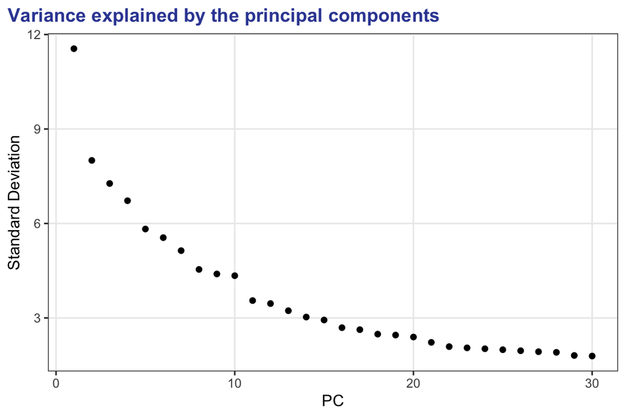

```r
ElbowPlot(obj, ndims = 30) + theme_project() +
  labs(title = "Variance explained by the principal components")
```

**Why 30 principal components.** The elbow of the variance plot is around 10 to 15 components. We kept 30 because too few components can erase rare populations (microglia, vascular cells), whereas a few extra components mainly add noise to a map used only for visualisation.

**Why we did not re-cluster.** The 27 subclasses come from a hierarchical annotation of more than 6 million nuclei [1]. A clustering of a subsample would be less reliable and not comparable with the atlas.

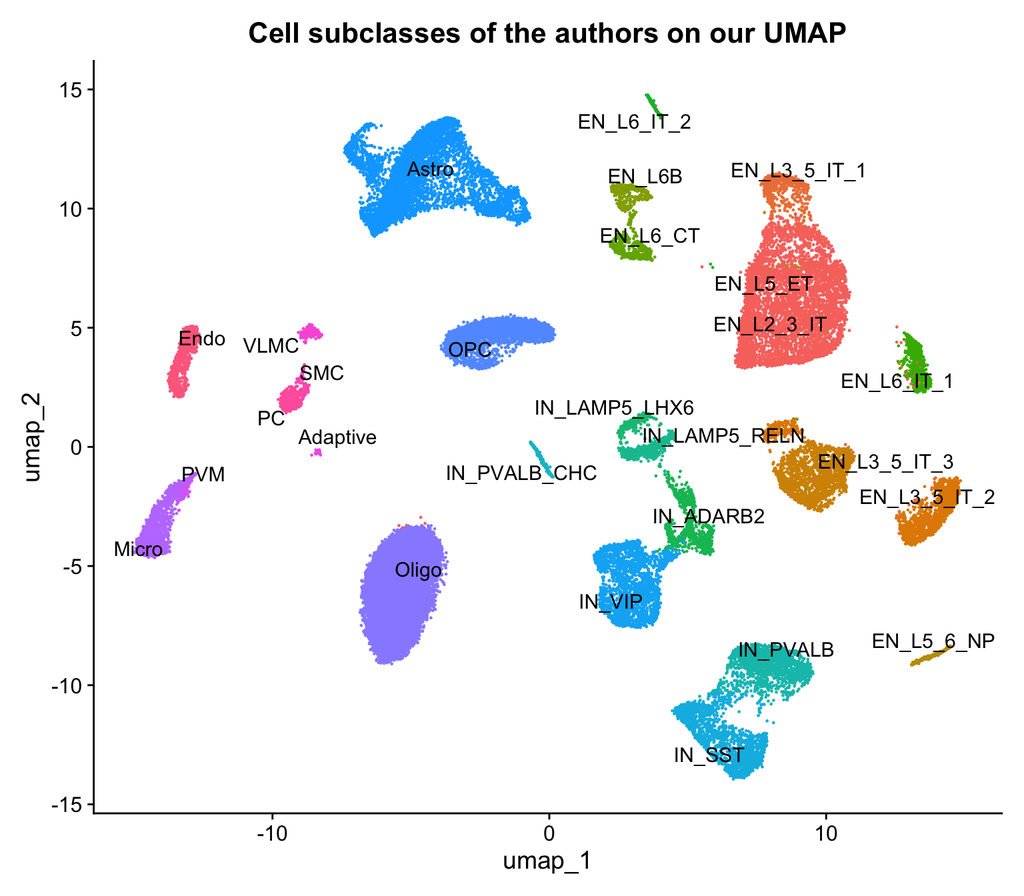

Figure 5

```r
p_PP_F04 <- DimPlot(obj, reduction = "umap", group.by = "subclass", label = TRUE, repel = TRUE) + NoLegend() +
  labs(title = "Cell subclasses of the authors on our UMAP")
p_PP_F04
save_figure(p_PP_F04, "PP_F04_umap_subclass", fig_dir, width = 8, height = 7)
```

**Figure PP-F04 – UMAP of 44,588 nuclei coloured by cell subclass.** UMAP computed on the first 30 principal components of the 2,000 most variable genes; subclasses as annotated by the authors [1].

**TipHow to read**

Each dot is a nucleus; nuclei with similar gene expression are close. Distances between islands are not meaningful, only which nuclei group together.

**ImportantInterpretation**

No marker gene is given for adaptive immune cells in these sources: they are not shown.

```r
# Neuronal subclasses (1): markers of Figure 2d of Lee et al. [1], two per subclass
markers_psychad_neurons <- list(
  EN_L2_3_IT    = c("CUX2", "ONECUT2"),
  EN_L3_5_IT_1  = c("MME", "COL22A1"),
  EN_L3_5_IT_2  = c("GABRG1", "TPBG"),
  EN_L3_5_IT_3  = c("TRABD2A", "MKX"),
  EN_L5_6_NP    = c("HTR2C", "NPSR1"),
  EN_L5_ET      = c("POU3F1", "SYT2"),
  EN_L6B        = c("NPFFR2", "LRAT"),
  EN_L6_CT      = c("SULF1", "SMIM36"),
  EN_L6_IT_1    = c("THEMIS", "ADAMTS3"),
  EN_L6_IT_2    = c("POSTN", "SMYD1"),
  IN_ADARB2     = c("NDNF", "KCNG1"),
  IN_LAMP5_LHX6 = c("CHST9", "CA3"),
  IN_LAMP5_RELN = c("PID1", "TRPC3"),
  IN_PVALB      = c("MYO5B", "SULF1"),
  IN_PVALB_CHC  = c("CA8", "PVALB"),
  IN_SST        = c("SST", "MAFB"),
  IN_VIP        = c("VIP", "CHRNA2"))

# Markers of the taxonomy used to name the cell types, Ma et al. 2022 [5]
# (a gene can mark several of our subclasses: RORB for the three L3-5 IT, OPRK1 for the two L6 IT;
#  CCN2 is the current name of CTGF)
markers_ma <- list(
  EN_L2_3_IT    = "PCDH8",
  EN_L3_5_IT_1  = "RORB", EN_L3_5_IT_2 = "RORB", EN_L3_5_IT_3 = "RORB",
  EN_L5_6_NP    = "HTR2C",
  EN_L5_ET      = c("FEZF2", "BCL11B", "POU3F1"),
  EN_L6B        = "CCN2",
  EN_L6_CT      = "SYT6",
  EN_L6_IT_1    = "OPRK1", EN_L6_IT_2 = "OPRK1",
  IN_ADARB2     = c("ADARB2", "KCNG1"),
  IN_LAMP5_LHX6 = c("LAMP5", "LHX6"),
  IN_LAMP5_RELN = c("LAMP5", "RELN"),
  IN_PVALB      = "PVALB",
  IN_PVALB_CHC  = "PVALB",
  IN_SST        = "SST",
  IN_VIP        = "VIP",
  Astro         = "AQP4",
  Micro         = "P2RY12",
  Endo          = "FLT1")

# Non-neuronal subclasses: file of the authors, Supplementary Table 10 of Lee et al. [1]
# We keep the subclass-level markers (tier 1, no subtype); the other rows are markers of finer subtypes
panel <- read.csv("../01_DATA/markers/PsychAD_SupplementaryTable10.csv")
panel <- panel[panel$tier == 1 & panel$subtype == "" & !panel$class %in% c("EN", "IN"), ]
markers_psychad_other <- split(panel$marker, panel$subclass)

# One table: one row per marker gene and expected subclass, with its source
as_table <- function(markers, source) {
  data.frame(gene = unlist(markers), expected = rep(names(markers), lengths(markers)), source = source)
}
marker_table <- rbind(as_table(markers_psychad_neurons, "Lee et al., Fig. 2d"),
                      as_table(markers_psychad_other,   "Lee et al., Suppl. Table 10"),
                      as_table(markers_ma,              "Ma et al. 2022"))
marker_table <- marker_table[marker_table$gene %in% rownames(obj), ]    # genes present in our data
rownames(marker_table) <- NULL
table(marker_table$source)
```

```
        Lee et al., Fig. 2d Lee et al., Suppl. Table 10
                         34                          18
             Ma et al. 2022
                         25
```

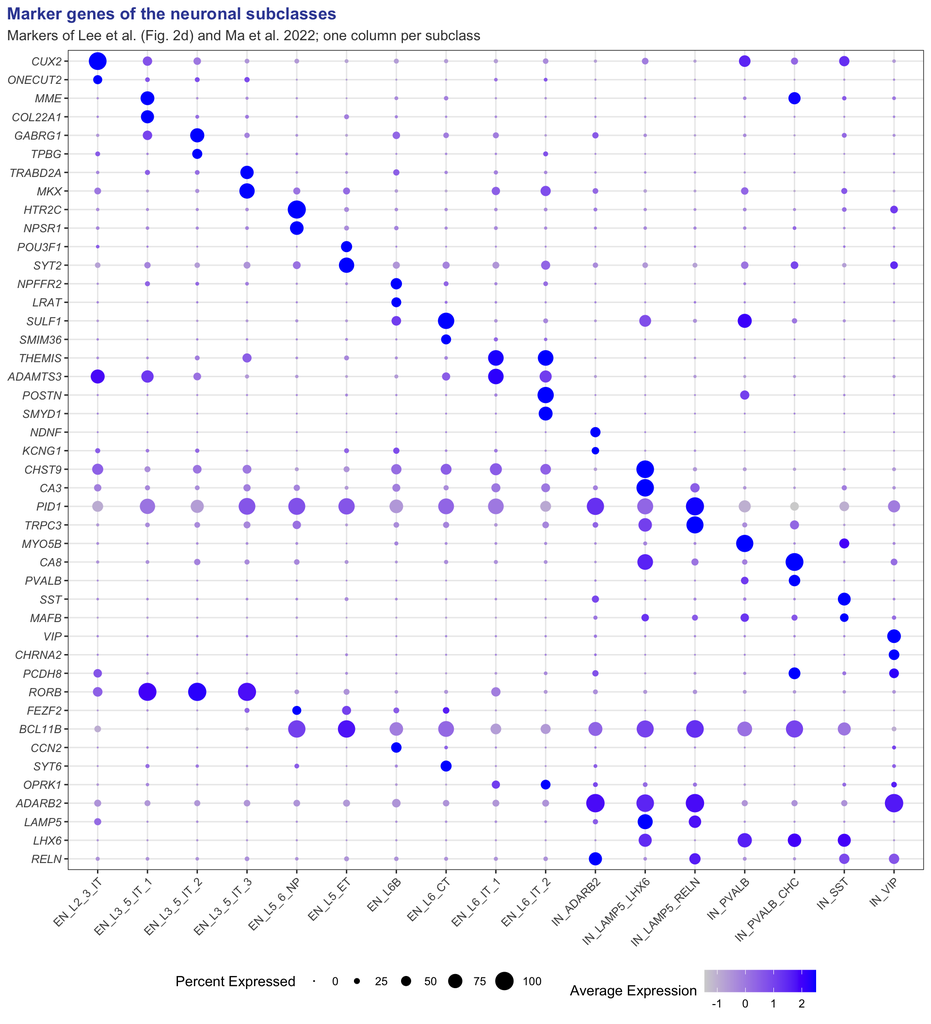

Figure 6

```r
neuron_subclasses <- names(markers_psychad_neurons)
neuron_genes <- unique(marker_table$gene[marker_table$expected %in% neuron_subclasses])

obj_neurons <- subset(obj, subset = subclass %in% neuron_subclasses)
obj_neurons$subclass <- factor(obj_neurons$subclass, levels = neuron_subclasses)

p_PP_F05 <- DotPlot(obj_neurons, features = rev(neuron_genes), group.by = "subclass") + coord_flip() +
  labs(x = NULL, y = NULL, title = "Marker genes of the neuronal subclasses",
       subtitle = "Markers of Lee et al. (Fig. 2d) and Ma et al. 2022; one column per subclass") +
  theme_project() +
  theme(axis.text.x = element_text(angle = 45, hjust = 1), axis.text.y = element_text(face = "italic"))
p_PP_F05
save_figure(p_PP_F05, "PP_F05_markers_neurons", fig_dir, width = 10, height = 11)
```

**Figure PP-F05 – Expression of marker genes in the 17 neuronal subclasses.** Markers of Figure 2d of [1] and of the taxonomy used to name the cell types [5], on the 19,505 neuronal nuclei of the subsample. Dot size: percentage of nuclei of the subclass that express the gene; colour: mean expression, scaled across subclasses.

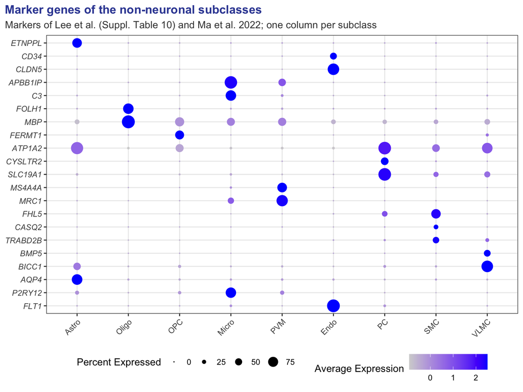

Figure 7

```r
other_subclasses <- c("Astro", "Oligo", "OPC", "Micro", "PVM", "Endo", "PC", "SMC", "VLMC")
other_genes <- unique(marker_table$gene[marker_table$expected %in% other_subclasses])

obj_other <- subset(obj, subset = subclass %in% other_subclasses)
obj_other$subclass <- factor(obj_other$subclass, levels = other_subclasses)

p_PP_F06 <- DotPlot(obj_other, features = rev(other_genes), group.by = "subclass") + coord_flip() +
  labs(x = NULL, y = NULL, title = "Marker genes of the non-neuronal subclasses",
       subtitle = "Markers of Lee et al. (Suppl. Table 10) and Ma et al. 2022; one column per subclass") +
  theme_project() +
  theme(axis.text.x = element_text(angle = 45, hjust = 1), axis.text.y = element_text(face = "italic"))
p_PP_F06
save_figure(p_PP_F06, "PP_F06_markers_non_neuronal", fig_dir, width = 8, height = 6)
```

**Figure PP-F06 – Expression of marker genes in the 9 non-neuronal subclasses.** Subclass-level markers of Supplementary Table 10 of [1] and markers of [5], on the 25,003 non-neuronal nuclei of the subsample. Same reading as Figure PP-F05.

**TipHow to read**

Each row is a gene, each column a subclass. The size of a dot is the percentage of nuclei of the subclass that express the gene; its colour is the mean expression. A good marker gives a large dark dot in its own subclass and small pale dots elsewhere: if the annotation is right, the dark dots form a diagonal.

**The same check in numbers.** For each marker gene, we look for the subclass where its mean expression is the highest, and compare it with the subclass it is supposed to mark.

```r
shown <- c(neuron_subclasses, other_subclasses)
in_shown <- obj$subclass %in% shown
expression <- LayerData(obj, layer = "data")[unique(marker_table$gene), in_shown]
subclass_of_nuclei <- factor(obj$subclass[in_shown], levels = shown)
membership <- fac2sparse(subclass_of_nuclei)                       # subclasses x nuclei, 1 = belongs
mean_expression <- as.matrix(expression %*% t(membership)) / rep(rowSums(membership), each = nrow(expression))
highest <- setNames(colnames(mean_expression)[apply(mean_expression, 1, which.max)], rownames(mean_expression))

marker_table$highest_in <- highest[marker_table$gene]
# A gene that marks several subclasses (e.g. RORB) is correct if it is highest in one of them
expected_sets <- tapply(marker_table$expected, paste(marker_table$gene, marker_table$source), unique)
marker_table$match <- mapply(function(g, s, h) h %in% expected_sets[[paste(g, s)]],
                             marker_table$gene, marker_table$source, marker_table$highest_in)

n_match   <- sum(marker_table$match)
n_markers <- nrow(marker_table)
aggregate(match ~ source, data = marker_table, FUN = function(x) paste0(sum(x), " / ", length(x)))
```

| source | match |
| --- | --- |
| Lee et al., Fig. 2d | 31 / 34 |
| Lee et al., Suppl. Table 10 | 18 / 18 |
| Ma et al. 2022 | 18 / 25 |

```r
marker_table[!marker_table$match, ]                                # markers that are not highest where expected
```

|  | gene | expected | source | highest_in | match |
| --- | --- | --- | --- | --- | --- |
| 17 | THEMIS | EN_L6_IT_1 | Lee et al., Fig. 2d | EN_L6_IT_2 | FALSE |
| 26 | TRPC3 | IN_LAMP5_RELN | Lee et al., Fig. 2d | PC | FALSE |
| 32 | MAFB | IN_SST | Lee et al., Fig. 2d | PVM | FALSE |
| 53 | PCDH8 | EN_L2_3_IT | Ma et al. 2022 | IN_PVALB_CHC | FALSE |
| 58 | FEZF2 | EN_L5_ET | Ma et al. 2022 | EN_L5_6_NP | FALSE |
| 61 | CCN2 | EN_L6B | Ma et al. 2022 | VLMC | FALSE |
| 62 | SYT6 | EN_L6_CT | Ma et al. 2022 | Micro | FALSE |
| 65 | ADARB2 | IN_ADARB2 | Ma et al. 2022 | IN_LAMP5_RELN | FALSE |
| 68 | LHX6 | IN_LAMP5_LHX6 | Ma et al. 2022 | IN_SST | FALSE |
| 70 | RELN | IN_LAMP5_RELN | Ma et al. 2022 | IN_ADARB2 | FALSE |

**67 of 77 marker genes are highest in their expected subclass.** The table above lists the exceptions.

**ImportantInterpretation**

- **67 of 77 marker genes are highest in their expected subclass**, including all 18 markers of the non-neuronal subclasses chosen by the authors and 31 of the 34 neuronal markers of their Figure 2d: our data reproduce the diagonal of Figure 2d of [1], which confirms both our reading of the file and the annotation of the authors.
- The three exceptions from Figure 2d are near misses. *THEMIS* is highest in EN_L6_IT_2 rather than EN_L6_IT_1, but it marks both L6 IT subclasses, as in Figure 2d. *TRPC3* and *MAFB* are highest in a non-neuronal subclass (pericytes, perivascular macrophages), but among neurons they mark their own subclass (Figure PP-F05).
- The markers of the primate taxonomy [5] agree less well (18 of 25), mostly because some of them mark broader groups than our subclasses: *LHX6* marks all the interneurons of one developmental origin (SST, PVALB, LAMP5_LHX6), *ADARB2* and *RELN* those of the other origin (VIP, ADARB2, LAMP5_RELN), and *FEZF2* all deep-layer neurons. *SYT6* and *CCN2* are highest in a non-neuronal subclass (microglia, VLMC), but among neurons they mark EN_L6_CT and EN_L6B (Figure PP-F05). *PCDH8* does not mark EN_L2_3_IT in our data.

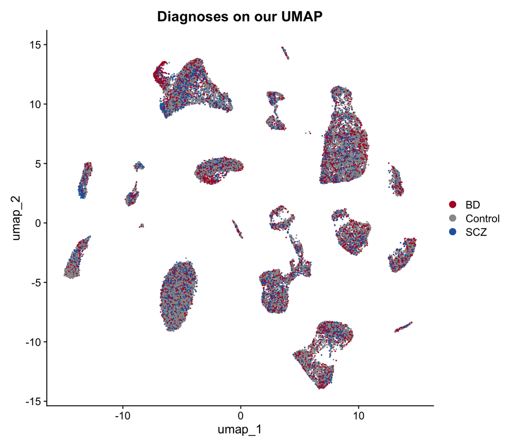

Figure 8

```r
p_PP_F07 <- DimPlot(obj, reduction = "umap", group.by = "group", shuffle = TRUE, cols = col_groups) +
  labs(title = "Diagnoses on our UMAP")
p_PP_F07
save_figure(p_PP_F07, "PP_F07_umap_group", fig_dir, width = 8, height = 7)
```

**Figure PP-F07 – UMAP of 44,588 nuclei coloured by diagnosis.** Same UMAP as Figure PP-F04.

**TipHow to read**

If one diagnosis formed its own island, the disease would create a new cell state. Mixed colours mean that the same cell types are found in the three groups.

## Step 9 – Pseudobulk: one sample per donor and cell type (input of Q2 and Q5)

**What we do and why.** For each donor, we sort its nuclei by cell type and add up their counts, gene by gene. For example, all the microglia of donor 1 become one “sample”, all its astrocytes another one. We obtain one sample per donor and cell type, as if the cells of each type had been sorted and sequenced together (pseudobulk). Each donor then counts once in the tests, which avoids treating 5,000 nuclei of the same brain as 5,000 people [2]. We use all the nuclei here, not the 200-nuclei subsample. This matrix is the input of Q2 and Q5.

The 27 cell types are kept for every donor, even when a donor has none of a type (empty sample): Q2 removes the samples with too few nuclei (E7 threshold).

```r
if (!file.exists(pseudobulk_file)) {
  pb <- build_pseudobulk(h5ad_file, meta, sel, gene_table$name)     # about 10 minutes
  saveRDS(pb, pseudobulk_file)
  write.csv(pb$description, file.path(proc_dir, "pseudobulk_column_description.csv"), row.names = FALSE)
}
pb <- readRDS(pseudobulk_file)
dim(pb$counts)                       # expected: 34,176 genes x 6,048 columns (224 donors x 27 subclasses)
```

```
[1] 34176  6048
```

```r
head(pb$description)
```

| donor | subclass | column | n_nuclei | group | age | sex | ancestry |
| --- | --- | --- | --- | --- | --- | --- | --- |
| Donor_672 | Adaptive | Donor_672__Adaptive | 1 | Control | 57 | male | African |
| Donor_672 | Astro | Donor_672__Astro | 111 | Control | 57 | male | African |
| Donor_672 | EN_L2_3_IT | Donor_672__EN_L2_3_IT | 1153 | Control | 57 | male | African |
| Donor_672 | EN_L3_5_IT_1 | Donor_672__EN_L3_5_IT_1 | 177 | Control | 57 | male | African |
| Donor_672 | EN_L3_5_IT_2 | Donor_672__EN_L3_5_IT_2 | 494 | Control | 57 | male | African |
| Donor_672 | EN_L3_5_IT_3 | Donor_672__EN_L3_5_IT_3 | 374 | Control | 57 | male | African |

**Checks.**

```r
subclasses <- sort_subclasses(unique(as.character(meta$subclass)))
expected   <- as.vector(t(unclass(nuclei_donor_subclass)[sel$donor_id, subclasses]))
empty      <- pb$description$n_nuclei == 0

data.frame(
  check = c("columns (donor x subclass)",
            "numbers of nuclei identical to the table of Step 5",
            "empty columns (subclass absent in a donor)",
            "empty columns contain only zeros",
            "raw integer counts",
            paste0("columns with >= ", nuclei_min, " nuclei (usable in Q2)")),
  result = sapply(list(ncol(pb$counts),
                       all(pb$description$n_nuclei == expected),
                       sum(empty),
                       all(colSums(pb$counts[, empty, drop = FALSE]) == 0),
                       all(pb$counts@x == round(pb$counts@x)),
                       sum(pb$description$n_nuclei >= nuclei_min)), as.character))
```

| check | result |
| --- | --- |
| columns (donor x subclass) | 6048 |
| numbers of nuclei identical to the table of Step 5 | TRUE |
| empty columns (subclass absent in a donor) | 444 |
| empty columns contain only zeros | TRUE |
| raw integer counts | TRUE |
| columns with >= 20 nuclei (usable in Q2) | 4116 |

**TipHow to read**

The matrix has one row per gene and one column per donor and subclass. The number of nuclei of every column is identical to the table of Step 5, and empty columns contain only zeros. Counts are raw integers: the Q2 tools (DESeq2, edgeR, limma-voom) compute their own normalisation.

# Conclusion

| Element | Result | Figure |
| --- | --- | --- |
| Donors analysed | 224 (121 controls, 49 SCZ, 54 BD), one brain bank | PP-F01 |
| Main limit | genetic ancestry confounded with diagnosis | PP-F02 |
| Data quality | good, already filtered by the authors; nuclei, hence almost no mitochondrial reads | PP-F03 |
| Annotation | 27 subclasses of the authors, recovered by our pipeline and by their marker genes | PP-F04 to PP-F06 |
| New cell types in disease? | no: the three groups are mixed on the UMAP | PP-F07 |
| Input of Q1 | nuclei per donor and subclass (all 1,123,085 nuclei) | - |
| Input of Q2 and Q5 | pseudobulk matrix (all nuclei), raw counts, 4,116 usable columns | - |
| Input of Q4 | Seurat object, 44,588 nuclei (at most 200 per donor), normalised | - |

**What this gives to the next questions.** We compare 224 adult donors from a single brain bank (121 controls, 49 SCZ, 54 BD), selected with criteria fixed in advance. The data are of good quality, and the 27 subclasses of the atlas are recovered by our pipeline and by their marker genes; the diseases do not create new cell types. Every question therefore works on the same donors and the same cell types: Q1 on the number of nuclei per donor and subclass, Q2 and Q5 on the pseudobulk matrix (all nuclei), Q4 on the Seurat object. The main limit to keep in mind in every question is that genetic ancestry is confounded with the diagnosis: it is adjusted for in every model, but the direct SCZ vs BD comparison must be read with caution.

# Limits

- **Ancestry confounded with diagnosis**: adjusted for and stratified, but it cannot be removed.
- **QC and doublet detection not redone**: we rely on the filtering of the authors [1].
- **No post-mortem interval and no information on treatments**: covariates limited to age, sex and ancestry.
- **Subsample of 200 nuclei per donor**: used only for the Seurat object; every statistical analysis uses all nuclei.
- **Donors with few nuclei**: 12 donors with fewer than 1,000 nuclei (minimum 61).

# List of figures

| Figure | File | What it shows |
| --- | --- | --- |
| PP-F01 | `PP_F01_age_by_group` | age at death per group |
| PP-F02 | `PP_F02_ancestry_by_group` | ancestry per group |
| PP-F03 | `PP_F03_qc_by_group` | quality of the nuclei |
| PP-F04 | `PP_F04_umap_subclass` | UMAP by subclass |
| PP-F05 | `PP_F05_markers_neurons` | marker genes of the neuronal subclasses |
| PP-F06 | `PP_F06_markers_non_neuronal` | marker genes of the non-neuronal subclasses |
| PP-F07 | `PP_F07_umap_group` | UMAP by diagnosis |

```r
sort(list.files(fig_dir, pattern = "\\.png$"))
```

```
[1] "PP_F01_age_by_group.png"         "PP_F02_ancestry_by_group.png"
[3] "PP_F03_qc_by_group.png"          "PP_F04_umap_subclass.png"
[5] "PP_F05_markers_neurons.png"      "PP_F06_markers_non_neuronal.png"
[7] "PP_F07_umap_group.png"
```

# References

1. Lee D. et al. (2026). Single-cell atlas of transcriptomic vulnerability across brain disorders. *Nature*, 657, 988–1002. doi:10.1038/s41586-025-09573-z
2. Squair J. W. et al. (2021). Confronting false discoveries in single-cell differential expression. *Nature Communications*, 12, 5692.
3. Hao Y. et al. (2024). Dictionary learning for integrative, multimodal and scalable single-cell analysis (Seurat v5). *Nature Biotechnology*, 42, 293–304.
4. Yang H., Clarence T., Scott M. R. et al. (2026). Lifespan single-cell transcriptomic atlas of the human prefrontal cortex. *Nature*, 657, 1003–1015. doi:10.1038/s41586-026-10271-7
5. Ma S. et al. (2022). Molecular and cellular evolution of the primate dorsolateral prefrontal cortex. *Science*, 377, eabo7257.